# Egzaminas

## 3.5 Grafikas 2

Pastebėję, jog socialinės išlaidos pakankamai skiriasi tarp LT is ES28, Jūs nusprendėte nubraižyti stulpelinį grafiką, kuriame būtų pavaizduotos visų ES (t.y. 28!) šalių išlaidos socialiniai sričiai bendrai (“Social protection”) % nuo BVP. Naudokite 2017 metų rodiklius. Tam jog matytųsi ES28 vidurkis nubraižykite jį į grafiką kaip horizontalią liniją.

Jums gali reikėti atsisiųsti reikiamą Eurostat dataset iš naujo. Stulpeliai turėtų būti surikiuoti didėjančia tvarka, jų viršuje pateikiamos stulpelių reikšmės.

Grafikas turėtų atrodyti daugmaž taip: https://i2.wp.com/lithuanian-economy.net/wp-content/uploads/2019/03/private_expenditue_MTEP_2017.jpeg?resize=768%2C427

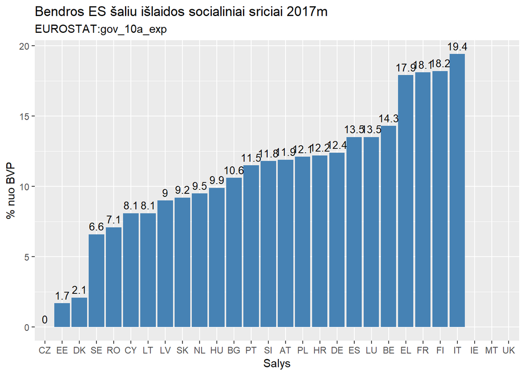

```r
gov_10a_exp <- get_eurostat("gov_10a_exp",stringsAsFactors = FALSE)
gov_10a_exp <- as.data.frame(gov_10a_exp)
sp <- gov_10a_exp %>% filter(
        cofog99 == "GF10",
        geo %in% c("BE","BG","CZ","DK","DE","EE","IE",
                   "EL","ES","FR","HR","IT","CY","LV",
                   "LT","LU","HU","MT","NL","AT","PL",
                   "PT","RO","SI","SK","FI","SE","UK"),
        sector == "S1314",
        unit == "PC_GDP",
        time == "2017-01-01",
        na_item == "TE"
)

ggplot(sp, aes(x = reorder(geo,values), y=values))+
        geom_bar(stat = "Identity", fill = "steelblue")+
        geom_text(aes(label=values), vjust= -0.5, size=3.5)+
        labs(title= "Bendros ES šalių išlaidos socialiniai sričiai 2017m",
             subtitle= "EUROSTAT:gov_10a_exp",
             x= "Salys",
             y= "% nuo BVP")
```

## 3.6 Vertinimas

Pateikite trumpą situacijos vertinimą remiantis iki šiol atlikta duomenų analizę. Pateikite savo įžvalgas, kaip būtų galima spręsti žemų pensijų problemas ateityje. Drąsiai galite remtis Europos Komisijos ataskaita bei rekomendacijomis Lietuvai.

- Rekomendacija: https://ec.europa.eu/info/sites/info/files/file_import/2019-european-semester-country-specific-recommendation-commission-recommendation-lithuania_en.pdf
- Ataskaita : https://ec.europa.eu/info/sites/info/files/file_import/2019-european-semester-country-report-lithuania_lt.pdf

```r
#Parašykite apie 200 (+- 20) žodžių.
#Rašykite VIETOJ Lore ipsum... teksto t.y. tarpe tarp abiejų kabučių.
#Jeigu norite žinoti kiek žodžių parašėte, galite runninti tik šit snippet' jo kampytyje nuspaudę ant žalio trikampio rodančio į dešinę

str1 <-
"
Lietuvos pensijų sistema nėra veiksminga apsaugant pagyvenusius žmones nuo skurdo ir socialinės atskirties. Trumpalaikei perpektyvoje tai šiek tiek sumažins skurdo lygi tarp pensijinio amžiaus žmonių, tačiau žvelgiant į ateitį, nauda gali būti labai nedidelė arba išvis jos nelikti. Valstybė, leisdama pensijų fondų reklamą, elgiasi neetiškai ir neatsakingai, juolab
kad pati neprisiima atsakomybės pensijų fondų įmonių nemokumo atveju. Būtina ne reklamuoti kaupiamąsias pensijas, o visapusiškai aiškinti galimas rizikas, pateikiant kraštutinumus pensijų fondo veiklos rezultatų. Tik tokia valstybės pozicija bus teisinga. Kaupiamos pensijos dydžio negarantuoja nei valstybė, nei privatūs pensijų fondai. Kaupiama pensija nėra apsaugota. Todėl nesekmingų investicijų metu visos pasekmės atitenka pensijų sistemos reformos dalyviams, kurie kaupia lėšas. Reformos dalyviui nesuteiktos garantijos, kad sumažėjusią papildomos senatvės pensijos dalį kompensuos išmokos, gaunamos iš pensijų fondų, todėl yra rizika, kad asmuo, kaupdamas lėšas antros pakopos pensijų fonduose, negaus didesnės senatvės pensijos. Tad manau būtina stiprinti teisinius pensijų fondo lėšų saugiklius. Čia svarbi vadinamoji “ankstyvojo signalo” sistema, kuri padėtų laiku susiorientuoti situacijoje ir imtis atitinkamų apsaugos priemonių. Manau, kad valstybė galėtų prisiimti bent dalinę atsakomybę. Šiuo atveju įstatymų leidėjas turėtų gerai pamąstyti dėlgalimybės įtvirtinti privalomąjį antrosios pakopos kaupimą. Tokiu būdu prievolė kaupti pensiją būtų atsverta atitinkama valstybės pareiga.


"
sapply(strsplit(str1," "),length)
```

```
## [1] 194
```

## 3.7 Darbo užbaigimo ir ship’inimo instrukcija:

- Sumegzkite šį dokumentą į `html`, jeigu Jūsų kode yra klaidų ir sumezgimas neveikia, išsaugokite šį failą tiesiog “File -> save”
- Savo Github paskyroje sukurkite repo “exam”
- Pushinkit lokalią repo į Github. Direktorijoje turi būti 2 failai: “StudNr_Vardas_Pavardė.Rmd” ir “StudNr_Vardas_Pavardė.html”
- Įsitikinkite jog Githube guli repo kopija ir repo url įrašykite į google docs J stulpelį: https://docs.google.com/spreadsheets/d/1H_ts3wTKYZ4rocmFseR2YJtZHfhJ543MUWsTTa7x5Kc/edit?usp=sharing